# Phylogeography and connectivity of the Pseudocalanus (Copepoda: Calanoida) species complex in the eastern North Pacific and the Pacific Arctic Region | Journal of Plankton Research | Oxford Academic

## RESULTS

A total of 822 COI sequences were obtained for the four *Pseudocalanus* species collected from the GoA, PWS and the Chukchi and Beaufort Seas (Table I; GenBank accession nos KU141424–KU142246). The aligned sequence length used for the analyses ranged from 518 to 536 bp (Table II). *Pseudocalanus minutus* and *P. newmani* were found throughout the entire study region, whereas *P. acuspes* was restricted to the PAR and *P. mimus* was confined to the eastern North Pacific sampling location. Few individuals of *P. acuspes* and *P. mimus* were sequenced from the eastern North Pacific and the PAR, respectively (Table I), despite considerable effort to find them within our collections. The presence of *P. mimus* in the Arctic Ocean has also been confirmed through sequencing the 28S ribosomal RNA gene (GenBank accession no: EF460783).

Table II:

Summary of intraspecific variation for COI sequences for *Pseudocalanus* from the eastern North Pacific and PAR during 2013

| Affinity | Species | *N* | BP | *H* | *π* | SD | *H*<sub>d</sub> | SD |
| --- | --- | --- | --- | --- | --- | --- | --- | --- |
| Arctic | *P. acuspes* | 297 | 518 | 59 | 3.3 × 10<sup>−3</sup> | 3.6 × 10<sup>−4</sup> | 0.661 | 0.032 |
|  | *P. minutus* | 188 | 535 | 13 | 1.6 × 10<sup>−3</sup> | 1.3 × 10<sup>−4</sup> | 0.606 | 0.027 |
| Temperate | *P. mimus* | 129 | 536 | 52 | 7.8 × 10<sup>−3</sup> | 4.3 × 10<sup>−4</sup> | 0.914 | 0.020 |
|  | *P. newmani* | 208 | 529 | 54 | 6.9 × 10<sup>−3</sup> | 6.6 × 10<sup>−4</sup> | 0.807 | 0.020 |

*N*, number of individuals sequenced; BP, base pair sequence length; *H*, number of haplotypes; *H*<sub>d</sub>, haplotype diversity; SD, standard deviation; *π*, nucleotide diversity.

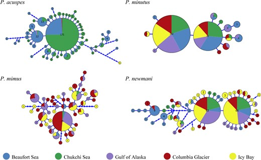

Fig. 3.

Cytochrome oxidase I haplotype networks for *P. acuspes*, *P. minutus*, *P. mimus* and *P. newmani*. Each circle represents a unique haplotype; sizes are scaled to the number of individuals expressing that particular haplotype. Each node represents a single bp mutation.

[Open in new tab](https://academic.oup.com/view-large/figure/62328791/fbw025f03.tif)Download slide

Table III:

Pairwise Φ<sub>ST</sub> distances between samples of *P. acuspes* from the eastern North Pacific and PAR during 2013

| *P. acuspes* Samples | Beaufort Sea A1-50 | Beaufort Sea A2-200 | Beaufort Sea A6-50 | Beaufort Sea A6-200 | Beaufort Sea A6-1000 | Chukchi Sea BF007 | Chukchi Sea KF007 | Chukchi Sea KF011 | Chukchi Sea KF017 | Chukchi Sea SF020 | Chukchi Sea TF004 |
| --- | --- | --- | --- | --- | --- | --- | --- | --- | --- | --- | --- |
| A1-50 |  | 0.215 | 0.902 | 0.001 | **0.001** | **0.000** | **0.000** | **0.000** | **0.000** | **0.000** | 0.061 |
| A2-200 | 0.016 |  | 0.242 | 0.130 | 0.008 | **0.000** | **0.000** | 0.051 | **0.000** | 0.047 | 0.264 |
| A6-50 | 0.000 | 0.024 |  | 0.004 | 0.017 | **0.000** | **0.000** | **0.000** | **0.000** | **0.001** | 0.034 |
| A6-200 | 0.113 | 0.023 | 0.199 |  | 0.907 | 0.282 | **−0.003** | 0.464 | 0.139 | 0.336 | 0.057 |
| A6-1000 | **0.168** | 0.051 | 0.247 | 0.000 |  | 0.410 | **−0.002** | 0.507 | 0.271 | 0.323 | 0.062 |
| BF007 | **0.247** | **0.092** | **0.375** | 0.004 | 0.000 |  | 0.657 | 0.580 | 0.253 | 0.412 | 0.007 |
| KF007 | **0.310** | **0.127** | **0.414** | **0.024** | **0.013** | 0.000 |  | 0.377 | 0.118 | 0.436 | 0.007 |
| KF011 | **0.142** | 0.049 | **0.294** | 0.000 | 0.000 | 0.000 | 0.005 |  | 0.457 | 1.000 | 0.096 |
| KF017 | **0.249** | **0.105** | **0.343** | 0.014 | 0.005 | 0.005 | 0.007 | 0.000 |  | 0.582 | 0.018 |
| SF020 | **0.137** | 0.054 | **0.305** | 0.006 | 0.000 | 0.000 | 0.000 | 0.000 | 0.000 |  | 0.088 |
| TF004 | 0.103 | 0.019 | 0.220 | 0.138 | 0.161 | 0.290 | 0.320 | 0.170 | 0.236 | 0.216 |  |

Φ<sub>ST</sub> values are below and *P* values are above the diagonal. Bold numbers indicate significant values after sequential Bonferroni correction (*α* = 0.05).

Table IV:

Pairwise Φ<sub>ST</sub> distances between samples of *P. newmani* from the eastern North Pacific and PAR during 2013

| *P. newmani* Stations | Beaufort Sea A2-200 | Beaufort Sea A2-1000 | Beaufort Sea A6-200 | Chukchi Sea BF007 | Chukchi Sea KF007 | Chukchi Sea KF017 | PWS CG | PWS IB | GoA GAK1 | GoA GAK4 | GoA GAK8 |
| --- | --- | --- | --- | --- | --- | --- | --- | --- | --- | --- | --- |
| A2-200 |  | 0.721 | 0.079 | 0.011 | **0.001** | 0.006 | **0.000** | **0.000** | **0.000** | **0.000** | **0.000** |
| A2-1000 | 0.000 |  | 0.056 | 0.005 | **0.000** | 0.004 | **0.000** | **0.000** | **0.000** | **0.000** | **0.000** |
| A6-200 | 0.140 | 0.171 |  | 0.544 | 0.287 | 0.512 | 0.558 | 0.013 | 0.112 | 0.129 | 0.116 |
| BF007 | 0.239 | 0.296 | 0.000 |  | 0.201 | 0.574 | 0.429 | 0.056 | 0.345 | 0.132 | 0.051 |
| KF007 | **0.423** | **0.480** | 0.087 | 0.066 |  | 0.900 | 0.742 | 0.476 | 0.668 | 0.991 | 0.786 |
| KF017 | 0.314 | 0.370 | 0.000 | 0.000 | 0.000 |  | 0.926 | 0.394 | 0.607 | 0.761 | 0.484 |
| CG | **0.347** | **0.393** | 0.000 | 0.000 | 0.000 | 0.000 |  | 0.061 | 0.563 | 0.447 | 0.436 |
| IB | **0.553** | **0.605** | 0.153 | 0.071 | 0.000 | 0.000 | 0.020 |  | 0.970 | 0.225 | 0.447 |
| GAK1 | **0.449** | **0.508** | 0.105 | 0.028 | 0.000 | 0.000 | 0.000 | 0.000 |  | 0.695 | 0.698 |
| GAK4 | **0.433** | **0.486** | 0.097 | 0.052 | 0.000 | 0.000 | 0.000 | 0.013 | 0.000 |  | 1.000 |
| GAK8 | **0.488** | **0.552** | 0.154 | 0.119 | 0.000 | 0.000 | 0.000 | 0.000 | 0.000 | 0.000 |  |

Φ<sub>ST</sub> values are below and *P* values are above the diagonal. Bold numbers indicate significant values after sequential Bonferroni correction (*α* = 0.05).

Table V:

Pairwise Φ<sub>ST</sub> distances between samples of *P. minutus* from the eastern North Pacific and PAR during 2013

| *P. minutus* Samples | Beaufort Sea A2-200 | Beaufort Sea A6-200 | Beaufort Sea A6-1000 | Chukchi Sea BF007 | Chukchi Sea KF007 | Chukchi Sea KF011 | Chukchi Sea KF017 | PWS CG | PWS IB | GoA GAK1 |
| --- | --- | --- | --- | --- | --- | --- | --- | --- | --- | --- |
| A2-200 |  | 0.418 | 0.694 | 0.614 | 0.604 | 0.243 | 0.747 | 0.317 | 0.218 | 0.736 |
| A6-200 | 0.000 |  | 0.375 | 0.698 | 0.292 | 0.716 | 0.214 | 0.101 | 0.032 | 0.092 |
| A6-1000 | 0.000 | 0.000 |  | 0.610 | 0.833 | 0.335 | 0.908 | 0.801 | 0.732 | 0.801 |
| BF007 | 0.000 | 0.010 | 0.000 |  | 0.524 | 0.494 | 0.614 | 0.432 | 0.221 | 0.435 |
| KF007 | 0.000 | 0.000 | 0.000 | 0.000 |  | 0.212 | 0.822 | 0.845 | 0.740 | 0.744 |
| KF011 | 0.041 | 0.000 | 0.090 | 0.000 | 0.142 |  | 0.156 | 0.146 | 0.054 | 0.133 |
| KF017 | 0.000 | 0.033 | 0.000 | 0.000 | 0.000 | 0.156 |  | 0.738 | 0.893 | 0.733 |
| CG | 0.000 | 0.041 | 0.000 | 0.000 | 0.000 | 0.111 | 0.000 |  | 0.694 | 0.506 |
| IB | 0.020 | 0.085 | 0.000 | 0.031 | 0.000 | 0.228 | 0.000 | 0.000 |  | 0.449 |
| GAK1 | 0.000 | 0.039 | 0.000 | 0.000 | 0.000 | 0.120 | 0.000 | 0.000 | 0.000 |  |

Table VI:

Pairwise Φ<sub>ST</sub> distances between samples of *P. mimus* from the eastern North Pacific and PAR during 2013

| *P. mimus* Stations | PWS CG | PWS IB | GoA GAK1 | GoA GAK4 | GoA GAK8 |
| --- | --- | --- | --- | --- | --- |
| CG |  | 0.067 | **0.001** | 0.844 | 0.856 |
| IB | 0.022 |  | 0.006 | 0.553 | 0.409 |
| GAK1 | **0.140** | 0.105 |  | 0.027 | 0.017 |
| GAK4 | 0.000 | 0.000 | 0.141 |  | 0.978 |
| GAK8 | 0.000 | 0.000 | 0.178 | 0.000 |  |

Φ<sub>ST</sub> values are below and *P* values are above the diagonal. Bold numbers indicate significant values after sequential Bonferroni correction (*α* = 0.05).

Table VII:

Analysis of MOlecular VAriance (AMOVA) for *Pseudocalanus* species from the eastern North Pacific and PAR during 2013

|  | Source of variation | DF | Sum of squares | Variance components | Percent of variation | Fixation indices | *P* value |  |  |  |  |  |  |
| --- | --- | --- | --- | --- | --- | --- | --- | --- | --- | --- | --- | --- | --- |
| Arctic | *P. acuspes* |  |  |  |  |  |  |  |  |  |  |  |  |
|  | Among regions | 1 | 8.672 | **0.0460** | 5.45 | Φ<sub>CT</sub> = 0.0545 | 0.0306 ± 0.0018 |  |  |  |  |  |  |
|  | Among samples | 9 | 15.363 | **0.0395** | 4.68 | Φ<sub>SC</sub> = 0.0495 | 0.0008 ± 0.0003 |  |  |  |  |  |  |
|  | within regions |  |  |  |  |  |  |  |  |  |  |  |  |
|  | Within samples |  |  |  |  |  |  | 282 | 213.791 | **0.7581** | 89.86 | Φ<sub>ST</sub> = 0.1014 | 0.0000 ± 0.0000 |
|  | Total | 292 | 237.826 | 0.8437 |  |  |  |  |  |  |  |  |  |
|  | *P. minutus* |  |  |  |  |  |  |  |  |  |  |  |  |
|  | Among regions | 3 | 1.619 | 0.0048 | 1.17 | Φ<sub>CT</sub> = 0.0117 | 0.2354 ± 0.0038 |  |  |  |  |  |  |
|  | Among samples | 6 | 2.125 | **−**0.0035 | **−**0.85 | Φ<sub>SC</sub> = **−**0.0086 | 0.4866 ± 0.0054 |  |  |  |  |  |  |
|  | within regions |  |  |  |  |  |  |  |  |  |  |  |  |
|  | Within samples |  |  |  |  |  |  | 174 | 70.555 | 0.4055 | 99.68 | Φ<sub>ST</sub> = 0.0032 | 0.4172 ± 0.0047 |
|  | Total | 183 | 74.299 | 0.4068 |  |  |  |  |  |  |  |  |  |
| Temperate | *P. mimus* |  |  |  |  |  |  |  |  |  |  |  |  |
|  | Among regions | 1 | 3.074 | **−**0.0355 | **−**1.65 | Φ<sub>CT</sub> = **−**0.0165 | 0.6045 ± 0.0049 |  |  |  |  |  |  |
|  | Among samples | 3 | 14.349 | **0.1245** | 5.80 | Φ<sub>SC</sub> = 0.0571 | 0.0063 ± 0.0008 |  |  |  |  |  |  |
|  | within regions |  |  |  |  |  |  |  |  |  |  |  |  |
|  | Within samples |  |  |  |  |  |  | 119 | 244.690 | **2.0562** | 95.85 | Φ<sub>ST</sub> = 0.0415 | 0.0046 ± 0.0006 |
|  | Total | 123 | 262.113 | 2.1453 |  |  |  |  |  |  |  |  |  |
|  | *P. newmani* |  |  |  |  |  |  |  |  |  |  |  |  |
|  | Among regions | 3 | 65.476 | **0.446** | 21.9 | Φ<sub>CT</sub> = 0.2190 | 0.0210 ± 0.0014 |  |  |  |  |  |  |
|  | Among samples | 7 | 18.015 | 0.0672 | 3.30 | Φ<sub>SC</sub> = 0.0423 | 0.1536 ± 0.0036 |  |  |  |  |  |  |
|  | within regions |  |  |  |  |  |  |  |  |  |  |  |  |
|  | Within samples |  |  |  |  |  |  | 184 | 280.231 | **1.5230** | 74.79 | Φ<sub>ST</sub> = 0.2521 | 0.0000 ± 0.0000 |
|  | Total | 194 | 363.723 | 2.0363 |  |  |  |  |  |  |  |  |  |

Samples are grouped by region (Chukchi Sea, Beaufort Sea, GoA, Icy Bay and Columbia Glacier). Bold numbers indicate significant values (*P* = 0.05). DF, degrees of freedom.

Low numbers of *P. acuspes* were found in the GoA and PWS, which constrained the Migrate-N models of gene flow to the PAR. Similarly, low numbers of *P. mimus* were found in the PAR, which constrained the model scenarios of gene flow to the eastern North Pacific. Marginal likelihood outputs predicted the Full model to be the best pathway for gene flow between sampled populations of *P. acuspes* and *P. mimus* (Table VIII). These results indicated strong bidirectional gene flow between the Chukchi and Beaufort Seas for *P. acuspes* and between the GoA and PWS for *P. mimus*. Marginal likelihood outputs predicted the Part-North model, simulating gene flow from the GoA north through the Chukchi Sea and into the Beaufort Sea, to be the best fit for sampled populations of *P. newmani* (Table VIII). All model results for *P. acuspes*, *P. mimus* and *P. newmani* gave good Bayesian unimodal posterior distributions. Marginal likelihood outputs predicted the Full model, which allowed bidirectional gene flow between sampled populations with geographical restrictions, to be the best fit for *P. minutus* (Table VIII). However, Bayesian posterior distributions were not unimodal, but instead showed noisy distributions for all migration rates tested. Models were further tested using Metropolis-Hastings as the Bayes-proposals and longer-running models, with long-chain increments set to 10 000. These parameter changes did not result in cleaner or more unimodal posterior distributions.

Table VIII:

Bayesian predictions for custom migration models using Migrate-N for *Pseudocalanus* from the eastern North Pacific and PAR during 2013

|  | *P. acuspes* | Full | South-to-North | North-to-South |  |
| --- | --- | --- | --- | --- | --- |
| Arctic | Bezier ImL | **−1841.328** | **−**1979.752 | **−**1965.854 |  |
|  | LBF (Besier) | **0.000** | **−**138.423 | **−**124.526 |  |
|  | Model Probability | **1.000** | 0.000 | 0.000 |  |
|  | Choice | **1 (best)** | 3 | 2 |  |
|  | *P. minutus* | Full | All-North | Part-North | South |
|  | Bezier ImL | **−972.779** | **−**983.676 | **−**978.970 | **−**1145.543 |
|  | LBF (Besier) | **0.000** | **−**10.897 | **−**6.190 | **−**172.764 |
|  | Model Probability | **0.998** | 0.000 | 0.002 | 0.000 |
|  | Choice | **1 (best)** | 3 | 2 | 4 |
|  | *P. mimus* | Full | Out-PWS | In-PWS |  |
| Temperate | Bezier ImL | **−1491.687** | **−**1565.433 | **−**1589.876 |  |
|  | LBF (Besier) | **0.000** | **−**73.746 | **−**98.189 |  |
|  | Model Probability | **1.000** | 0.000 | 0.000 |  |
|  | Choice | **1 (best)** | 2 | 3 |  |
|  | *P. newmani* | Full | All-North | Part-North | South |
|  | Bezier ImL | **−**1679.050 | **−**1674.089 | **−1669.113** | **−**1806.162 |
|  | LBF (Besier) | **−**9.936 | **−**4.976 | **0.000** | **−**137.048 |
|  | Model Probability | 0.000 | 0.007 | **0.993** | 0.000 |
|  | Choice | 3 | 2 | **1 (best)** | 4 |

Bold values indicate best model choice.

## DISCUSSION

An important component of forecasting how marine ecosystems will respond to climate change is understanding how individual species’ distributions and abundances will change with warming trends. Multiyear studies of the mesozooplankton communities from the Chukchi Sea have revealed differing responses on a species level in warm years versus cold years (Matsuno *et al*., 2011; Questel *et al*., 2013; Ershova *et al*., 2015). Specifically, *Pseudocalanus* spp., which numerically dominate the copepod assemblages, are least abundant in colder years (Questel *et al*., 2013; Ershova *et al*., 2015). Overall, the temperate *P. newmani* is the most prevalent of the four *Pseudocalanus* species across the Chukchi Sea (Matsuno *et al*., 2011; Questel *et al*., 2013; Ershova *et al*., 2015) exhibiting broader spatial distributions in warmer years and, consequently, pushing faunal barriers for Arctic species northward (Ershova *et al*., 2015). Interestingly, this exemplifies how even very closely related species, with similar niches and geographical distributions, elicit very different responses to changing environmental conditions.

Results from this study suggest *P. newmani* will likely exhibit greater resilience to climate change, as it was found in high abundances throughout the entire study region and displayed a dominant northward gene flow pattern, concurrent with local hydrography. Conversely, it is plausible that *P. acuspes* will experience, and perhaps already has done so, range contraction, where it would be restricted to the colder Arctic environment. *Pseudocalanus acuspes* was very rare in the GoA and PWS regions, being restricted to cold glacial fjords, and thus showed very low levels of population connectivity between the eastern North Pacific and PAR. Overall, results from our Migrate-N model simulations indicate high levels of connectivity between established populations of each *Pseudocalanus* species in the Arctic and eastern North Pacific. Shifting species boundaries will increase the need to understand how climate effects will cascade through marine ecosystems. In particular, northward movement of boreal generalist species has great potential to alter Arctic food webs (Kortsch *et al*., 2015).

Results from the Migrate-N model scenarios indicated that there is a strong degree of population connectivity between North Pacific and Arctic populations of each of the four species, with bidirectional gene flow occurring between geographically adjacent populations. However, posterior distributions were quite noisy and resolution could not be improved by changing model parameters for *P. minutus*. These results could indicate that either this species has extremely high rates of contemporary gene flow or that it recently went through a population bottleneck, for which single locus mitochondrial data would not be informative enough on their own to definitively model gene flow. In the North Atlantic, *P. minutus* had the lowest level of genetic structuring of the *Pseudocalanus* species studied, with most of the variance explained by within-population comparisons (Aarbakke *et al*., 2014). Bayesian skyline tests indicated that these populations of *P. minutus* underwent population expansion during the current interglacial 25 000–10 000 YBP (Aarbakke *et al*., 2014). *Pseudocalanus minutus* was found to be evenly distributed across the Bering Sea, with highest abundances occurring over the shelf region (Bailey *et al*., 2015). Nucleotide and haplotype diversities expressed within that region were comparable to those found in our study 2.01 × 10<sup>**−**3</sup> and 0.670 (Bailey *et al*., 2015) versus 1.6 × 10<sup>−3</sup> and 0.606, respectively.

*Pseudocalanus acuspes* appeared to be the most abundant of the four species in the Arctic populations. Despite sharing one highly frequent haplotype, populations of this species showed significant differentiation between the two regions in this study. Our results differ from a prior study, which showed no significant differences among populations (Sevigny *et al*., 1989). This discrepancy is most likely the result of the reduced ability of allozymes to resolve population structure, as well as analyzing individual *P. acuspes* from a relict population (Bedford Basin) in the North Atlantic that has been genetically isolated since the last glacial maximum. The prospect of a relict population was also observed in the Gulf of Finland, where mitochondrial sequence data revealed a high degree of variance among samples of *P. acuspes*, yet populations exhibited extremely low mitochondrial diversity (*H*<sub>d</sub> = 0.024) (Aarbakke *et al*., 2014), suggesting that these populations started to diverge 200 000–50 000 YBP.

*Pseudocalanus mimus* and *P. newmani* were found throughout the samples collected from the eastern North Pacific. However, the lack of *P. mimus* within the Chukchi and Beaufort Seas was most likely a result of the abnormally cold temperatures experienced in the PAR for the 2013 open water season (Weingartner *et al*., 2014), which may have impeded the survival and reproduction of this species on the Bering Sea shelf. Nucleotide and haplotype diversities were high for all populations of *P. mimus* and *P. newmani*, complementing the patterns observed for the Bering Sea populations (Bailey *et al*., 2015). Aarbakke *et al*. (2014) and Sevigny *et al*. (1989) both observed high levels of sequence diversity for *P. newmani*, with approximations that populations in the North Atlantic have remained stable in size for over 250 000 years (Aarbakke *et al*., 2014).

Estimates of gene flow for the Full model scenarios for both *P. minutus* and *P. mimus* indicated that population connectivity is bidirectional between the two sampled fjord systems of PWS, as well as within the northern GoA. This flow scenario was also incorporated into the accepted Part-North model for *P. newmani*. These patterns complement the regional hydrographic flow, where the ACC from the GoA enters PWS through Hinchinbrook Entrance and exits through Montague Strait. During the summer months, hydrographic flow decreases in intensity, causing flow to reverse direction (Halverson *et al*., 2013).

The moderate levels of haplotype diversity among Arctic species observed in this study may be a direct reflection of population size, where Arctic species have smaller population sizes and ranges than temperate species, thus resulting in lower haplotype diversities. This phenomenon has been observed in other marine copepods (e.g. *Calanus finmarchicus* and *Nannocalanus minor*), which display low mitochondrial diversity and small effective population sizes, most likely resulting from a population contraction during the last glacial maximum (Bucklin and Wiebe, 1998). The low nucleotide diversity, low numbers of alleles over a large number of individuals and moderate *H*<sub>d</sub> recorded for *P. minutus* in this study are likely indications that the evolutionary history of this species entailed genetic isolation or a population bottleneck associated with the closing of the Bering Strait during the Pleistocene Ice Ages (1.6 MYA to 10 000 YBP) due to lower sea level exposing the Bering Land Bridge (Sancetta, 1983).

The phylogeographic analyses presented here confirm the biogeographic distribution of four sibling species of *Pseudocalanus*, which live sympatrically in the eastern North Pacific and PAR (Frost, 1989). Estimates of population connectivity based on COI sequence variation indicated that *Pseudocalanus* species inhabiting the eastern North Pacific and PAR show high levels of gene flow. Similarly, Aarbakke *et al*. (2011) observed a high degree of connectivity among populations of *P. moultoni* in the North Atlantic/Arctic sector. Strong gene flow despite large geographic distances has been observed among the cosmopolitan copepod *Clausocalanus* spp. (Blanco-Bercial *et al*., 2011) and *Calanus sinicus* (Huang *et al*., 2014).

Our analyses also revealed gene flow patterns for *P. acuspes*, *P. newmani* and *P. mimus* that agree with local hydrographic flow. For instance, gene flow models indicate a northward flow for populations of *P. newmani* in the GoA through the Chukchi Sea and into the Beaufort Sea, reflecting the dominant northward flow of water masses through the Bering Strait and into the PAR. The temperate species *P. newmani* and the Arctic species *P. minutus* were abundant in all sampling regions, yet genetic structuring was stronger for *P. newmani* compared to *P. minutus*. *Pseudocalanus mimus* (temperate species) and *P. acuspes* (Arctic species) were found in extremely low abundances in Arctic and temperate samples, respectively. These patterns indicate that physical environmental conditions in the eastern North Pacific and PAR, including hydrography and ocean currents, serve as both pathways of exchange and barriers to gene flow for planktonic marine copepods.

## ACKNOWLEDGEMENTS

We would like to thank the captains and crews of the *M/V Tiglax*, *R/V Westward Wind* and the *R/V Norseman II* for their help during the various research cruises. In particular, we would like to thank the lead biologists Caryn Rea (ConocoPhilips), Michael Macrander (Shell) and Steinar Eldøy (Statoil) for their contributions to the CSESP project. Sequencing was conducted at the University of Alaska Fairbanks’ DNA Core lab facility. We would like to thank the Core Lab director, Ian Herriott, for his continued guidance with laboratory techniques.

## FUNDING

This work was primarily supported by the Chukchi Sea Environmental Studies Program (CSESP) funded by ConocoPhillips, Anchorage, AK; Shell Exploration and Production Company, Anchorage, AK and Statoil USA E + P, Inc., Anchorage, AK, with added contributions from UAF through the Northern Gulf of Alaska Applied Research Award. We would also like to thank BOEM for supporting the Transboundary Program as well as NPRB, EVOS and AOOS for supporting the Seward Line cruises, both of which provided samples for this study. Research reported in this publication was supported by an Institutional Development Award (IDeA) from the National Institute of General Medical Sciences of the National Institutes of Health to J.M.Q. (grant number P20GM103395).

## REFERENCES

Aagaard

,

K.

(

1984

) The Beaufort Undercurrent. In

Barnes

,

P. W.

,

Schell

,

D. M.

and

Reimnitz

,

E

. (eds.),

The Alaska Beaufort Sea: Ecosystems and Environments

.

Academic Press

,

New York

, pp.

47

–

71

.

Google Scholar

[Google Preview](https://www.google.com/search?q=The%20Alaska%20Beaufort%20Sea%3A%20Ecosystems%20and%20Environments&btnG=Search+Books&tbm=bks&tbo=1)

Find in my library

[WorldCat](https://www.worldcat.org/search?q=ti:The%20Alaska%20Beaufort%20Sea%3A%20Ecosystems%20and%20Environments&qt=advanced&dblist=638)

[COPAC](http://copac.ac.uk/search?ti=The%20Alaska%20Beaufort%20Sea%3A%20Ecosystems%20and%20Environments)

Aarbakke

,

O. N. S.

,

Bucklin

,

A.

,

Halsband

,

C.

and

Norrbin

,

F.

(

2011

)

Discovery of *Pseudocalanus moultoni* (Frost, 1989) in Northeast Atlantic waters based on mitochondrial COI sequence variation

.

J. Plankton Res.

,

33

,

1487

–

1495

.

Google Scholar

[Crossref](http://dx.doi.org/10.1093/plankt/fbr057)

[Find in my library](https://noaa.primo.exlibrisgroup.com/discovery/openurl?institution=01NOAA_INST&vid=01NOAA_INST:NOAA&&rft_id=info%3Adoi%2F10.1093%2Fplankt%2Ffbr057)

WorldCat

Aarbakke

,

O. N. S.

,

Bucklin

,

A.

,

Halsband

,

C.

and

Norrbin

,

F.

(

2014

)

Comparative phylogeography and demographic history of five sibling species of *Pseudocalanus* (Copepoda: Calanoida) in the North Atlantic Ocean

.

J. Exp. Mar. Biol. Ecol.

,

461

,

479

–

488

.

Google Scholar

[Crossref](http://dx.doi.org/10.1016/j.jembe.2014.10.006)

[Find in my library](https://noaa.primo.exlibrisgroup.com/discovery/openurl?institution=01NOAA_INST&vid=01NOAA_INST:NOAA&&rft_id=info%3Adoi%2F10.1016%2Fj.jembe.2014.10.006)

WorldCat

Altschul

,

S. F.

,

Madden

,

T. L.

,

Schäffer

,

A. A.

,

Zhang

,

J.

,

Zhang

,

Z.

,

Miller

,

W.

and

Lipman

,

D. J.

(

1997

)

Gapped BLAST and PSI-BLAST: a new generation of protein database search programs

.

Nucleic Acids Res.

,

25

,

3389

–

3402

.

Google Scholar

[Crossref](http://dx.doi.org/10.1093/nar/25.17.3389)

[Find in my library](https://noaa.primo.exlibrisgroup.com/discovery/openurl?institution=01NOAA_INST&vid=01NOAA_INST:NOAA&&rft_id=info%3Adoi%2F10.1093%2Fnar%2F25.17.3389)

[PubMed](http://www.ncbi.nlm.nih.gov/pubmed/9254694)

[WorldCat](https://www.worldcat.org/search?q=ti:Gapped%20BLAST%20and%20PSI-BLAST%3A%20a%20new%20generation%20of%20protein%20database%20search%20programs&qt=advanced&dblist=638)

Avise

,

J. C.

(

2000

)

Phylogeography: The History and Formation of Species

.

Harvard University Press

,

Cambridge, MA

.

Google Scholar

[Google Preview](https://www.google.com/search?q=Phylogeography%3A%20The%20History%20and%20Formation%20of%20Species&btnG=Search+Books&tbm=bks&tbo=1)

[Find in my library](https://noaa.primo.exlibrisgroup.com/discovery/openurl?institution=01NOAA_INST&vid=01NOAA_INST:NOAA&?sid=oup:orr&genre=book&title=Phylogeography%3a+The+History+and+Formation+of+Species&aulast=Avise&date=2000)

[WorldCat](https://www.worldcat.org/search?q=ti:Phylogeography%3A%20The%20History%20and%20Formation%20of%20Species&qt=advanced&dblist=638)

[COPAC](http://copac.ac.uk/search?ti=Phylogeography%3A%20The%20History%20and%20Formation%20of%20Species)

Bailey

,

J.

,

Rynearson

,

T.

and

Durbin

,

E. G.

(

2015

)

Species composition and abundance of copepods in the morphologically cryptic genus *Pseudocalanus* in the Bering Sea

.

Deep Sea Res. Part II Top. Stud. Oceanogr.

[doi:10.1016/j.dsr2.2015.04.017](http://dx.doi.org/10.1016/j.dsr2.2015.04.017)

.

Google Scholar

Find in my library

[WorldCat](https://www.worldcat.org/search?q=ti:Species%20composition%20and%20abundance%20of%20copepods%20in%20the%20morphologically%20cryptic%20genus%20Pseudocalanus%20in%20the%20Bering%20Sea&qt=advanced&dblist=638)

Beerli

,

P.

(

2004

)

Effect of unsampled populations on the estimation of population sizes and migration rates between sampled populations

.

Mol. Ecol.

,

13

,

827

–

836

.

Google Scholar

[Crossref](http://dx.doi.org/10.1111/mec.2004.13.issue-4)

[Find in my library](https://noaa.primo.exlibrisgroup.com/discovery/openurl?institution=01NOAA_INST&vid=01NOAA_INST:NOAA&&rft_id=info%3Adoi%2F10.1111%2Fmec.2004.13.issue-4)

[PubMed](http://www.ncbi.nlm.nih.gov/pubmed/15012758)

[WorldCat](https://www.worldcat.org/search?q=ti:Effect%20of%20unsampled%20populations%20on%20the%20estimation%20of%20population%20sizes%20and%20migration%20rates%20between%20sampled%20populations&qt=advanced&dblist=638)

Beerli

,

P.

(

2006

)

Comparison of Bayesian and maximum-likelihood inference of population genetic parameters

.

Bioinformatics

,

22

,

341

–

345

.

Google Scholar

[Crossref](http://dx.doi.org/10.1093/bioinformatics/bti803)

[Find in my library](https://noaa.primo.exlibrisgroup.com/discovery/openurl?institution=01NOAA_INST&vid=01NOAA_INST:NOAA&&rft_id=info%3Adoi%2F10.1093%2Fbioinformatics%2Fbti803)

[PubMed](http://www.ncbi.nlm.nih.gov/pubmed/16317072)

[WorldCat](https://www.worldcat.org/search?q=ti:Comparison%20of%20Bayesian%20and%20maximum-likelihood%20inference%20of%20population%20genetic%20parameters&qt=advanced&dblist=638)

Beerli

,

P.

(

2012

)

Migrate Documentation Version 3.2.1

.

Florida State University

,

Tallahasee, FL

, p.

119

.

[Google Scholar](https://scholar.google.com/scholar_lookup?title=Migrate%20Documentation%20Version%203.2.1&author=P.%20Beerli&publication_year=2012&book=Migrate%20Documentation%20Version%203.2.1)

[Google Preview](https://www.google.com/search?q=Migrate%20Documentation%20Version%203.2.1&btnG=Search+Books&tbm=bks&tbo=1)

[Find in my library](https://noaa.primo.exlibrisgroup.com/discovery/openurl?institution=01NOAA_INST&vid=01NOAA_INST:NOAA&?sid=oup:orr&genre=book&title=Migrate+Documentation+Version+3.2.1&aulast=Beerli&date=2012&spage=119)

[WorldCat](https://www.worldcat.org/search?q=ti:Migrate%20Documentation%20Version%203.2.1&qt=advanced&dblist=638)

[COPAC](http://copac.ac.uk/search?ti=Migrate%20Documentation%20Version%203.2.1)

Beerli

,

P.

and

Felsenstein

,

J.

(

2001

)

Maximum likelihood estimation of a migration matrix and effective population sizes in n subpopulations by using a coalescent approach

.

Proc. Natl Acad. Sci. USA

,

98

,

4563

–

4568

.

Google Scholar

[Crossref](http://dx.doi.org/10.1073/pnas.081068098)

[Find in my library](https://noaa.primo.exlibrisgroup.com/discovery/openurl?institution=01NOAA_INST&vid=01NOAA_INST:NOAA&&rft_id=info%3Adoi%2F10.1073%2Fpnas.081068098)

WorldCat

Blanco-Bercial

,

L.

,

Álvarez-Marqués

,

F.

and

Bucklin

,

A.

(

2011

)

Comparative phylogeography and connectivity of sibling species of the marine copepod *Clausocalanus* (Calanoida)

.

J. Exp. Mar. Biol. Ecol.

,

404

,

108

–

115

.

Google Scholar

[Crossref](http://dx.doi.org/10.1016/j.jembe.2011.05.011)

[Find in my library](https://noaa.primo.exlibrisgroup.com/discovery/openurl?institution=01NOAA_INST&vid=01NOAA_INST:NOAA&&rft_id=info%3Adoi%2F10.1016%2Fj.jembe.2011.05.011)

[WorldCat](https://www.worldcat.org/search?q=ti:Comparative%20phylogeography%20and%20connectivity%20of%20sibling%20species%20of%20the%20marine%20copepod%20Clausocalanus%20%28Calanoida%29&qt=advanced&dblist=638)

Brito

,

P. H.

and

Edwards

,

S. V.

(

2009

)

Multilocus phylogeography and phylogenetics using sequence-based markers

.

Genetica

,

135

,

439

–

455

.

Google Scholar

[Crossref](http://dx.doi.org/10.1007/s10709-008-9293-3)

[Find in my library](https://noaa.primo.exlibrisgroup.com/discovery/openurl?institution=01NOAA_INST&vid=01NOAA_INST:NOAA&&rft_id=info%3Adoi%2F10.1007%2Fs10709-008-9293-3)

[PubMed](http://www.ncbi.nlm.nih.gov/pubmed/18651229)

[WorldCat](https://www.worldcat.org/search?q=ti:Multilocus%20phylogeography%20and%20phylogenetics%20using%20sequence-based%20markers&qt=advanced&dblist=638)

Bucklin

,

A.

(

2000

) Methods for population genetic analysis of zooplankton. In

Harris

R.

,

Wiebe

P.

,

Lenz

J.

,

Skjodal

H. R.

and

Huntley

M

. (eds.),

ICES Zooplankton Methodology Manual

.

Academic Press

,

London

, pp.

533

–

570

.

Google Scholar

[Google Preview](https://www.google.com/search?q=ICES%20Zooplankton%20Methodology%20Manual&btnG=Search+Books&tbm=bks&tbo=1)

Find in my library

[WorldCat](https://www.worldcat.org/search?q=ti:ICES%20Zooplankton%20Methodology%20Manual&qt=advanced&dblist=638)

[COPAC](http://copac.ac.uk/search?ti=ICES%20Zooplankton%20Methodology%20Manual)

Bucklin

,

A.

,

Bentley

,

A. M.

and

Franzen

,

S. P.

(

1998

)

Distribution and relative abundance of *Pseudocalanus moultoni* and *P. newmani* (Copepoda: Calanoida) on Georges Bank using molecular identification of sibling species

.

Mar. Biol.

,

132

,

97

–

106

.

Google Scholar

[Crossref](http://dx.doi.org/10.1007/s002270050375)

[Find in my library](https://noaa.primo.exlibrisgroup.com/discovery/openurl?institution=01NOAA_INST&vid=01NOAA_INST:NOAA&&rft_id=info%3Adoi%2F10.1007%2Fs002270050375)

WorldCat

Bucklin

,

A.

,

Frost

,

B. W.

,

Bradford-Grieve

,

J.

,

Allen

,

L. D.

and

Copley

,

N. J.

(

2003

)

Molecular systematic and phylogenetic assessment of 34 calanoid copepod species of the Calanidae and Clausocalanidae

.

Mar. Biol.

,

142

,

333

–

343

.

Google Scholar

[Crossref](http://dx.doi.org/10.1007/s00227-002-0943-1)

[Find in my library](https://noaa.primo.exlibrisgroup.com/discovery/openurl?institution=01NOAA_INST&vid=01NOAA_INST:NOAA&&rft_id=info%3Adoi%2F10.1007%2Fs00227-002-0943-1)

[WorldCat](https://www.worldcat.org/search?q=ti:Molecular%20systematic%20and%20phylogenetic%20assessment%20of%2034%20calanoid%20copepod%20species%20of%20the%20Calanidae%20and%20Clausocalanidae&qt=advanced&dblist=638)

Bucklin

,

A.

,

Frost

,

B. W.

and

Kocher

,

T. D.

(

1995

)

Molecular systematics of six *Calanus* and three *Metridia* species (Calanoida: Copepoda)

.

Mar. Biol.

,

121

,

655

–

664

.

Google Scholar

[Crossref](http://dx.doi.org/10.1007/BF00349301)

[Find in my library](https://noaa.primo.exlibrisgroup.com/discovery/openurl?institution=01NOAA_INST&vid=01NOAA_INST:NOAA&&rft_id=info%3Adoi%2F10.1007%2FBF00349301)

[WorldCat](https://www.worldcat.org/search?q=ti:Molecular%20systematics%20of%20six%20Calanus%20and%20three%20Metridia%20species%20%28Calanoida%3A%20Copepoda%29&qt=advanced&dblist=638)

Bucklin

,

A.

,

Guarnieri

,

M.

,

Mcgillicuddy

,

D. J.

and

Sean Hill

,

R.

(

2001

)

Spring evolution of *Pseudocalanus* spp. abundance on Georges Bank based on molecular discrimination of *P. moultoni* and *P. newmani*

.

Deep Sea Res. Part II Top. Stud. Oceanogr.

,

48

,

589

–

608

.

Google Scholar

Crossref

Find in my library

WorldCat

Bucklin

,

A.

,

Mcgillicuddy

,

D. J.

Jr.,

Wiebe

,

P. H.

and

Davis

,

C. S.

(

2015

)

Habitat usage by the cryptic copepods *Pseudocalanus moultoni* and *P. newmani* on Georges Bank (Northwest Atlantic)

.

Cont. Shelf Res.

,

111

,

83

–

94

.

Google Scholar

[Crossref](http://dx.doi.org/10.1016/j.csr.2015.11.001)

[Find in my library](https://noaa.primo.exlibrisgroup.com/discovery/openurl?institution=01NOAA_INST&vid=01NOAA_INST:NOAA&&rft_id=info%3Adoi%2F10.1016%2Fj.csr.2015.11.001)

[WorldCat](https://www.worldcat.org/search?q=ti:Habitat%20usage%20by%20the%20cryptic%20copepods%20Pseudocalanus%20moultoni%20and%20P.%20newmani%20on%20Georges%20Bank%20%28Northwest%20Atlantic%29&qt=advanced&dblist=638)

Bucklin

,

A.

and

Wiebe

,

P. H.

(

1998

)

Low mitochondrial diversity and small effective population sizes of the copepods *Calanus finmarchicus* and *Nannocalanus minor*: possible impact of climatic variation during recent glaciation

.

J. Hered.

,

89

,

383

–

392

.

Google Scholar

[Crossref](http://dx.doi.org/10.1093/jhered/89.5.383)

[Find in my library](https://noaa.primo.exlibrisgroup.com/discovery/openurl?institution=01NOAA_INST&vid=01NOAA_INST:NOAA&&rft_id=info%3Adoi%2F10.1093%2Fjhered%2F89.5.383)

[PubMed](http://www.ncbi.nlm.nih.gov/pubmed/9768496)

WorldCat

Cleary

,

A. C.

,

Durbin

,

E. G.

,

Rynearson

,

T. A.

and

Bailey

,

J.

(

2015

)

Feeding by *Pseudocalanus* copepods in the Bering Sea: trophic linkages and a potential mechanism of niche partitioning

.

Deep Sea Res. Part II Top. Stud. Oceanogr.

[doi:10.1016/j.dsr2.2015.04.001](http://dx.doi.org/10.1016/j.dsr2.2015.04.001)

.

Google Scholar

Find in my library

WorldCat

Coachman

,

L. K.

and

Aagard

,

K.

(

1988

)

Transports through Bering Strait: annual and interannual variability

.

J. Geophys. Res.

,

93

,

15515

–

15539

.

Google Scholar

[Crossref](http://dx.doi.org/10.1029/JC093iC12p15535)

[Find in my library](https://noaa.primo.exlibrisgroup.com/discovery/openurl?institution=01NOAA_INST&vid=01NOAA_INST:NOAA&&rft_id=info%3Adoi%2F10.1029%2FJC093iC12p15535)

[WorldCat](https://www.worldcat.org/search?q=ti:Transports%20through%20Bering%20Strait%3A%20annual%20and%20interannual%20variability&qt=advanced&dblist=638)

Conover

,

R. J.

,

Herman

,

A. W.

,

Prinsenberg

,

S. J.

and

Harris

,

L. R.

(

1986

)

Distribution of and feeding by the copepod *Pseudocalanus* under fast ice during the arctic spring

.

Science

,

232

,

1245

–

1247

.

Google Scholar

[Crossref](http://dx.doi.org/10.1126/science.232.4755.1245)

[Find in my library](https://noaa.primo.exlibrisgroup.com/discovery/openurl?institution=01NOAA_INST&vid=01NOAA_INST:NOAA&&rft_id=info%3Adoi%2F10.1126%2Fscience.232.4755.1245)

[PubMed](http://www.ncbi.nlm.nih.gov/pubmed/17810744)

[WorldCat](https://www.worldcat.org/search?q=ti:Distribution%20of%20and%20feeding%20by%20the%20copepod%20Pseudocalanus%20under%20fast%20ice%20during%20the%20arctic%20spring&qt=advanced&dblist=638)

Corkett

,

C. J.

and

Mclaren

,

I. A.

(

1979

)

The biology of *Pseudocalanus*

.

Adv. Mar. Biol.

,

15

,

1

–

231

.

[Google Scholar](https://scholar.google.com/scholar_lookup?title=The%20biology%20of%20Pseudocalanus&author=C.%20J.%20Corkett&author=I.%20A.%20Mclaren&publication_year=1979&journal=Adv.%20Mar.%20Biol.&volume=15&pages=1-231)

Find in my library

[WorldCat](https://www.worldcat.org/search?q=ti:The%20biology%20of%20Pseudocalanus&qt=advanced&dblist=638)

Costa

,

K. G.

,

Filho

,

L. F. S. R.

,

Costa

,

R. M.

,

Vallinoto

,

M.

,

Schneider

,

H.

and

Sampaio

,

I.

(

2014

)

Genetic variability of *Acartia tonsa* (Crustacea: Copepoda) on the Brazilian coast

.

J. Plankton Res.

,

36

,

1419

–

1422

.

Google Scholar

[Crossref](http://dx.doi.org/10.1093/plankt/fbu080)

[Find in my library](https://noaa.primo.exlibrisgroup.com/discovery/openurl?institution=01NOAA_INST&vid=01NOAA_INST:NOAA&&rft_id=info%3Adoi%2F10.1093%2Fplankt%2Ffbu080)

[WorldCat](https://www.worldcat.org/search?q=ti:Genetic%20variability%20of%20Acartia%20tonsa%20%28Crustacea%3A%20Copepoda%29%20on%20the%20Brazilian%20coast&qt=advanced&dblist=638)

Coyle

,

K. O.

and

Pinchuk

,

A. I.

(

2003

)

Annual cycle of zooplankton abundance, biomass and production on the northern Gulf of Alaska shelf, October 1997 through October 2000

.

Fish. Oceanogr.

,

12

,

327

–

338

.

Google Scholar

[Crossref](http://dx.doi.org/10.1046/j.1365-2419.2003.00256.x)

[Find in my library](https://noaa.primo.exlibrisgroup.com/discovery/openurl?institution=01NOAA_INST&vid=01NOAA_INST:NOAA&&rft_id=info%3Adoi%2F10.1046%2Fj.1365-2419.2003.00256.x)

WorldCat

Danielson

,

S.

,

Curchitser

,

E.

,

Hedstrom

,

K.

,

Weingartner

,

T.

and

Stabeno

,

P.

(

2011

)

On ocean and sea ice modes of variability in the Bering Sea

.

J. Geophys. Res.

,

116

,

1

–

24

.

Google Scholar

[Crossref](http://dx.doi.org/10.1029/2011JC007389)

[Find in my library](https://noaa.primo.exlibrisgroup.com/discovery/openurl?institution=01NOAA_INST&vid=01NOAA_INST:NOAA&&rft_id=info%3Adoi%2F10.1029%2F2011JC007389)

[WorldCat](https://www.worldcat.org/search?q=ti:On%20ocean%20and%20sea%20ice%20modes%20of%20variability%20in%20the%20Bering%20Sea&qt=advanced&dblist=638)

Darnis

,

G.

,

Barber

,

D. G.

and

Fortier

,

L.

(

2008

)

Sea ice and the onshore-offshore gradient in pre-winter zooplankton assemblages in southeastern Beaufort Sea

.

J. Mar. Syst.

,

74

,

994

–

1011

.

Google Scholar

[Crossref](http://dx.doi.org/10.1016/j.jmarsys.2007.09.003)

[Find in my library](https://noaa.primo.exlibrisgroup.com/discovery/openurl?institution=01NOAA_INST&vid=01NOAA_INST:NOAA&&rft_id=info%3Adoi%2F10.1016%2Fj.jmarsys.2007.09.003)

[WorldCat](https://www.worldcat.org/search?q=ti:Sea%20ice%20and%20the%20onshore-offshore%20gradient%20in%20pre-winter%20zooplankton%20assemblages%20in%20southeastern%20Beaufort%20Sea&qt=advanced&dblist=638)

Day

,

R. H.

,

Weingartner

,

T. J.

,

Hopcroft

,

R. R.

,

Aerts

,

L. A. M.

,

Blanchard

,

A. L.

,

Gall

,

A. E.

,

Gallaway

,

B. J.

,

Hannay

,

D. E.

et al. . (

2013

)

The offshore northeastern Chukchi Sea, Alaska: a complex high-latitude ecosystem

.

Cont. Shelf Res.

,

67

,

147

–

165

.

Google Scholar

[Crossref](http://dx.doi.org/10.1016/j.csr.2013.02.002)

[Find in my library](https://noaa.primo.exlibrisgroup.com/discovery/openurl?institution=01NOAA_INST&vid=01NOAA_INST:NOAA&&rft_id=info%3Adoi%2F10.1016%2Fj.csr.2013.02.002)

[WorldCat](https://www.worldcat.org/search?q=ti:The%20offshore%20northeastern%20Chukchi%20Sea%2C%20Alaska%3A%20a%20complex%20high-latitude%20ecosystem&qt=advanced&dblist=638)

Erikson

,

K.

(

2015

) A time series investigation of the cryptic copepods Pseudocalanus spp. on the NW Atlantic continental shelf. Master's Thesis. University of Connecticut, 48 pp.

Ershova

,

E. A.

,

Hopcroft

,

R. R.

and

Kosobokova

,

K. N.

(

2015

)

Inter-annual variability of summer mesozooplankton communities of the western Chukchi Sea: 2004–2012

.

Polar Biol.

,

38

,

1461

–

1481

.

Google Scholar

[Crossref](http://dx.doi.org/10.1007/s00300-015-1709-9)

[Find in my library](https://noaa.primo.exlibrisgroup.com/discovery/openurl?institution=01NOAA_INST&vid=01NOAA_INST:NOAA&&rft_id=info%3Adoi%2F10.1007%2Fs00300-015-1709-9)

[WorldCat](https://www.worldcat.org/search?q=ti:Inter-annual%20variability%20of%20summer%20mesozooplankton%20communities%20of%20the%20western%20Chukchi%20Sea%3A%202004%E2%80%932012&qt=advanced&dblist=638)

Excoffier

,

L.

and

Lischer

,

H. E. L.

(

2010

)

Arlequin suite ver 3.5: a new series of programs to perform population genetics analyses under Linux and Windows

.

Mol. Ecol. Resour.

,

10

,

564

–

567

.

Google Scholar

[Crossref](http://dx.doi.org/10.1111/men.2010.10.issue-3)

[Find in my library](https://noaa.primo.exlibrisgroup.com/discovery/openurl?institution=01NOAA_INST&vid=01NOAA_INST:NOAA&&rft_id=info%3Adoi%2F10.1111%2Fmen.2010.10.issue-3)

[PubMed](http://www.ncbi.nlm.nih.gov/pubmed/21565059)

[WorldCat](https://www.worldcat.org/search?q=ti:Arlequin%20suite%20ver%203.5%3A%20a%20new%20series%20of%20programs%20to%20perform%20population%20genetics%20analyses%20under%20Linux%20and%20Windows&qt=advanced&dblist=638)

Folmer

,

O.

,

Black

,

M.

,

Hoeh

,

W.

,

Lutz

,

R.

and

Vrijenhoek

,

R.

(

1994

)

DNA primers for amplification of mitochondrial cytochrome c oxidase subunit I from diverse metazoan invertebrates

.

Mol. Mar. Biol. Biotechnol.

,

3

,

294

–

299

.

Google Scholar

[PubMed](http://www.ncbi.nlm.nih.gov/pubmed/7881515)

Find in my library

[WorldCat](https://www.worldcat.org/search?q=ti:DNA%20primers%20for%20amplification%20of%20mitochondrial%20cytochrome%20c%20oxidase%20subunit%20I%20from%20diverse%20metazoan%20invertebrates&qt=advanced&dblist=638)

Frost

,

B. W.

(

1974

)

*Calanus marshallae*, a new species of Calanoid copepod closely allied to the sibling species *C. finmarchicus* and *C. glacialis*

.

Mar. Biol.

,

26

,

77

–

79

.

Google Scholar

[Crossref](http://dx.doi.org/10.1007/BF00389089)

[Find in my library](https://noaa.primo.exlibrisgroup.com/discovery/openurl?institution=01NOAA_INST&vid=01NOAA_INST:NOAA&&rft_id=info%3Adoi%2F10.1007%2FBF00389089)

WorldCat

Frost

,

B. W.

(

1989

)

A taxonomy of the marine calanoid copepod genus *Pseudocalanus*

.

Can. J. Zool.

,

67

,

525

–

551

.

Google Scholar

[Crossref](http://dx.doi.org/10.1139/z89-077)

[Find in my library](https://noaa.primo.exlibrisgroup.com/discovery/openurl?institution=01NOAA_INST&vid=01NOAA_INST:NOAA&&rft_id=info%3Adoi%2F10.1139%2Fz89-077)

[WorldCat](https://www.worldcat.org/search?q=ti:A%20taxonomy%20of%20the%20marine%20calanoid%20copepod%20genus%20Pseudocalanus&qt=advanced&dblist=638)

Glenn

,

T.

and

Schable

,

N. A.

(

2005

)

Isolating microsatellite DNA loci

.

Methods Enzymol.

,

395

,

202

–

222

.

[Google Scholar](https://scholar.google.com/scholar_lookup?title=Isolating%20microsatellite%20DNA%20loci&author=T.%20Glenn&author=N.%20A.%20Schable&publication_year=2005&journal=Methods%20Enzymol.&volume=395&pages=202-222)

[PubMed](http://www.ncbi.nlm.nih.gov/pubmed/15865969)

Find in my library

[WorldCat](https://www.worldcat.org/search?q=ti:Isolating%20microsatellite%20DNA%20loci&qt=advanced&dblist=638)

Goetze

,

E.

(

2003

)

Cryptic speciation on the high seas; global phylogenetics of the copepod family Eucalanidae

.

Proc. R. Soc. Lond. B Biol. Sci.

,

270

,

2321

–

2331

.

Google Scholar

[Crossref](http://dx.doi.org/10.1098/rspb.2003.2505)

[Find in my library](https://noaa.primo.exlibrisgroup.com/discovery/openurl?institution=01NOAA_INST&vid=01NOAA_INST:NOAA&&rft_id=info%3Adoi%2F10.1098%2Frspb.2003.2505)

[WorldCat](https://www.worldcat.org/search?q=ti:Cryptic%20speciation%20on%20the%20high%20seas%3B%20global%20phylogenetics%20of%20the%20copepod%20family%20Eucalanidae&qt=advanced&dblist=638)

Goetze

,

E.

(

2005

)

Global population genetic structure and biogeography of the oceanic copepods *Eucalanus hyalinus* and *E. spinifer*

.

Evolution

,

59

,

2378

–

2398

.

Google Scholar

[PubMed](http://www.ncbi.nlm.nih.gov/pubmed/16396179)

Find in my library

[WorldCat](https://www.worldcat.org/search?q=ti:Global%20population%20genetic%20structure%20and%20biogeography%20of%20the%20oceanic%20copepods%20Eucalanus%20hyalinus%20and%20E.%20spinifer&qt=advanced&dblist=638)

Goetze

,

E.

and

Ohman

,

M. D.

(

2010

)

Integrated molecular and morphological biogeography of the calanoid copepod family Eucalanidae

.

Deep Sea Res. Part II Top. Stud. Oceanogr.

,

57

,

2110

–

2129

.

Google Scholar

[Crossref](http://dx.doi.org/10.1016/j.dsr2.2010.09.014)

[Find in my library](https://noaa.primo.exlibrisgroup.com/discovery/openurl?institution=01NOAA_INST&vid=01NOAA_INST:NOAA&&rft_id=info%3Adoi%2F10.1016%2Fj.dsr2.2010.09.014)

[WorldCat](https://www.worldcat.org/search?q=ti:Integrated%20molecular%20and%20morphological%20biogeography%20of%20the%20calanoid%20copepod%20family%20Eucalanidae&qt=advanced&dblist=638)

Grabbert

,

S.

,

Renz

,

J.

,

Hirche

,

H. J.

and

Bucklin

,

A.

(

2010

)

Species-specific PCR discrimination of species of the calanoid copepod *Pseudocalanus*, *P. acuspes* and *P. elongatus*, in the Baltic and North Seas

.

Hydrobiologia

,

652

,

289

–

297

.

Google Scholar

[Crossref](http://dx.doi.org/10.1007/s10750-010-0360-2)

[Find in my library](https://noaa.primo.exlibrisgroup.com/discovery/openurl?institution=01NOAA_INST&vid=01NOAA_INST:NOAA&&rft_id=info%3Adoi%2F10.1007%2Fs10750-010-0360-2)

WorldCat

Halverson

,

M. J.

,

Bélanger

,

C.

and

Gay

,

S. M.

(

2013

)

Seasonal transport variations in the straits connecting Prince William Sound to the Gulf of Alaska

.

Cont. Shelf Res.

,

63

,

63

–

78

.

Google Scholar

[Crossref](http://dx.doi.org/10.1016/j.csr.2012.06.017)

[Find in my library](https://noaa.primo.exlibrisgroup.com/discovery/openurl?institution=01NOAA_INST&vid=01NOAA_INST:NOAA&&rft_id=info%3Adoi%2F10.1016%2Fj.csr.2012.06.017)

[WorldCat](https://www.worldcat.org/search?q=ti:Seasonal%20transport%20variations%20in%20the%20straits%20connecting%20Prince%20William%20Sound%20to%20the%20Gulf%20of%20Alaska&qt=advanced&dblist=638)

Holm

,

S.

(

1979

)

A simple sequentially rejective multiple test procedure

.

Scand. J. Stat.

,

6

,

65

–

70

.

[Google Scholar](https://scholar.google.com/scholar_lookup?title=A%20simple%20sequentially%20rejective%20multiple%20test%20procedure&author=S.%20Holm&publication_year=1979&journal=Scand.%20J.%20Stat.&volume=6&pages=65-70)

Find in my library

[WorldCat](https://www.worldcat.org/search?q=ti:A%20simple%20sequentially%20rejective%20multiple%20test%20procedure&qt=advanced&dblist=638)

Holmborn

,

T.

,

Goetze

,

E.

,

Põllupüü

,

M.

and

Põllumäe

,

A.

(

2011

)

Genetic species identification and low genetic diversity in *Pseudocalanus acuspes* of the Baltic Sea

.

J. Plankton Res.

,

33

,

507

–

515

.

Google Scholar

[Crossref](http://dx.doi.org/10.1093/plankt/fbq113)

[Find in my library](https://noaa.primo.exlibrisgroup.com/discovery/openurl?institution=01NOAA_INST&vid=01NOAA_INST:NOAA&&rft_id=info%3Adoi%2F10.1093%2Fplankt%2Ffbq113)

[WorldCat](https://www.worldcat.org/search?q=ti:Genetic%20species%20identification%20and%20low%20genetic%20diversity%20in%20Pseudocalanus%20acuspes%20of%20the%20Baltic%20Sea&qt=advanced&dblist=638)

Hopcroft

,

R. R.

and

Kosobokova

,

K. N.

(

2010

)

Distribution and egg production of *Pseudocalanus* species in the Chukchi Sea

.

Deep Sea Res. Part II Top. Stud. Oceanogr.

,

57

,

49

–

56

.

Google Scholar

[Crossref](http://dx.doi.org/10.1016/j.dsr2.2009.08.004)

[Find in my library](https://noaa.primo.exlibrisgroup.com/discovery/openurl?institution=01NOAA_INST&vid=01NOAA_INST:NOAA&&rft_id=info%3Adoi%2F10.1016%2Fj.dsr2.2009.08.004)

[WorldCat](https://www.worldcat.org/search?q=ti:Distribution%20and%20egg%20production%20of%20Pseudocalanus%20species%20in%20the%20Chukchi%20Sea&qt=advanced&dblist=638)

Hopcroft

,

R. R.

,

Kosobokova

,

K. N.

and

Pinchuk

,

A. I.

(

2010

)

Zooplankton community patterns in the Chukchi Sea during summer 2004

.

Deep Sea Res. Part II Top. Stud. Oceanogr.

,

57

,

27

–

39

.

Google Scholar

[Crossref](http://dx.doi.org/10.1016/j.dsr2.2009.08.003)

[Find in my library](https://noaa.primo.exlibrisgroup.com/discovery/openurl?institution=01NOAA_INST&vid=01NOAA_INST:NOAA&&rft_id=info%3Adoi%2F10.1016%2Fj.dsr2.2009.08.003)

[WorldCat](https://www.worldcat.org/search?q=ti:Zooplankton%20community%20patterns%20in%20the%20Chukchi%20Sea%20during%20summer%202004&qt=advanced&dblist=638)

Horner

,

R.

and

Murphy

,

D.

(

1985

)

Species composition and abundance of zooplankton in the nearshore Beaufort Sea in winter-spring

.

Arctic

,

38

,

201

–

209

.

Google Scholar

[Crossref](http://dx.doi.org/10.14430/arctic2134)

[Find in my library](https://noaa.primo.exlibrisgroup.com/discovery/openurl?institution=01NOAA_INST&vid=01NOAA_INST:NOAA&&rft_id=info%3Adoi%2F10.14430%2Farctic2134)

[WorldCat](https://www.worldcat.org/search?q=ti:Species%20composition%20and%20abundance%20of%20zooplankton%20in%20the%20nearshore%20Beaufort%20Sea%20in%20winter-spring&qt=advanced&dblist=638)

Huang

,

Y.

,

Liu

,

G.

and

Chen

,

X.

(

2014

)

Molecular phylogeography and population genetic structure of the planktonic copepod *Calanus sinicus* Brodsky in the coastal waters of China

.

Acta Oceanol. Sin.

,

33

,

74

–

84

.

Google Scholar

[Crossref](http://dx.doi.org/10.1007/s13131-014-0542-2)

[Find in my library](https://noaa.primo.exlibrisgroup.com/discovery/openurl?institution=01NOAA_INST&vid=01NOAA_INST:NOAA&&rft_id=info%3Adoi%2F10.1007%2Fs13131-014-0542-2)

WorldCat

Knowles

,

L.

and

Maddison

,

W.

(

2002

)

Statistical phylogeography

.

Mol. Ecol.

,

11

,

2623

–

2635

.

[Google Scholar](https://scholar.google.com/scholar_lookup?title=Statistical%20phylogeography&author=L.%20Knowles&author=W.%20Maddison&publication_year=2002&journal=Mol.%20Ecol.&volume=11&pages=2623-2635)

[Crossref](http://dx.doi.org/10.1046/j.1365-294X.2002.01637.x)

[Find in my library](https://noaa.primo.exlibrisgroup.com/discovery/openurl?institution=01NOAA_INST&vid=01NOAA_INST:NOAA&&rft_id=info%3Adoi%2F10.1046%2Fj.1365-294X.2002.01637.x)

[PubMed](http://www.ncbi.nlm.nih.gov/pubmed/12453245)

[WorldCat](https://www.worldcat.org/search?q=ti:Statistical%20phylogeography&qt=advanced&dblist=638)

Kortsch

,

S.

,

Primicerio

,

R.

,

Fossheim

,

M.

,

Dolgov

,

A. V.

,

Aschan

,

M.

and

Kortsch

,

S.

(

2015

)

Climate change alters the structure of Arctic marine food webs due to poleward shifts of boreal generalists

.

Proc. R. Soc. Lond. B Biol. Sci.

,

282

,

1

–

9

.

Google Scholar

[Crossref](http://dx.doi.org/10.1098/rspb.2015.1546)

[Find in my library](https://noaa.primo.exlibrisgroup.com/discovery/openurl?institution=01NOAA_INST&vid=01NOAA_INST:NOAA&&rft_id=info%3Adoi%2F10.1098%2Frspb.2015.1546)

[WorldCat](https://www.worldcat.org/search?q=ti:Climate%20change%20alters%20the%20structure%20of%20Arctic%20marine%20food%20webs%20due%20to%20poleward%20shifts%20of%20boreal%20generalists&qt=advanced&dblist=638)

Lane

,

P. V. Z.

,

Llinás

,

L.

,

Smith

,

S. L.

and

Pilz

,

D.

(

2008

)

Zooplankton distribution in the western Arctic during summer 2002: hydrographic habitats and implications for food chain dynamics

.

J. Mar. Syst.

,

70

,

97

–

133

.

Google Scholar

[Crossref](http://dx.doi.org/10.1016/j.jmarsys.2007.04.001)

[Find in my library](https://noaa.primo.exlibrisgroup.com/discovery/openurl?institution=01NOAA_INST&vid=01NOAA_INST:NOAA&&rft_id=info%3Adoi%2F10.1016%2Fj.jmarsys.2007.04.001)

WorldCat

Librado

,

P.

and

Rozas

,

J.

(

2009

)

DnaSP v5: a software for comprehensive analysis of DNA polymorphism data

.

Bioinformatics

,

25

,

1451

–

1452

.

Google Scholar

[Crossref](http://dx.doi.org/10.1093/bioinformatics/btp187)

[Find in my library](https://noaa.primo.exlibrisgroup.com/discovery/openurl?institution=01NOAA_INST&vid=01NOAA_INST:NOAA&&rft_id=info%3Adoi%2F10.1093%2Fbioinformatics%2Fbtp187)

[PubMed](http://www.ncbi.nlm.nih.gov/pubmed/19346325)

[WorldCat](https://www.worldcat.org/search?q=ti:DnaSP%20v5%3A%20a%20software%20for%20comprehensive%20analysis%20of%20DNA%20polymorphism%20data&qt=advanced&dblist=638)

Llinás

,

L.

,

Pickart

,

R. S.

,

Mathis

,

J. T.

and

Smith

,

S. L.

(

2009

)

Zooplankton inside an Arctic Ocean cold-core eddy: probable origin and fate

.

Deep Sea Res. Part II Top. Stud. Oceanogr.

,

56

,

1290

–

1304

.

Google Scholar

[Crossref](http://dx.doi.org/10.1016/j.dsr2.2008.10.020)

[Find in my library](https://noaa.primo.exlibrisgroup.com/discovery/openurl?institution=01NOAA_INST&vid=01NOAA_INST:NOAA&&rft_id=info%3Adoi%2F10.1016%2Fj.dsr2.2008.10.020)

[WorldCat](https://www.worldcat.org/search?q=ti:Zooplankton%20inside%20an%20Arctic%20Ocean%20cold-core%20eddy%3A%20probable%20origin%20and%20fate&qt=advanced&dblist=638)

Machida

,

R. J.

,

Miya

,

M. U.

,

Nishida

,

M.

and

Nishida

,

S.

(

2006

)

Molecular phylogeny and evolution of the pelagic copepod genus *Neocalanus* (Crustacea: Copepoda)

.

Mar. Biol.

,

148

,

1071

–

1079

.

Google Scholar

[Crossref](http://dx.doi.org/10.1007/s00227-005-0140-0)

[Find in my library](https://noaa.primo.exlibrisgroup.com/discovery/openurl?institution=01NOAA_INST&vid=01NOAA_INST:NOAA&&rft_id=info%3Adoi%2F10.1007%2Fs00227-005-0140-0)

[WorldCat](https://www.worldcat.org/search?q=ti:Molecular%20phylogeny%20and%20evolution%20of%20the%20pelagic%20copepod%20genus%20Neocalanus%20%28Crustacea%3A%20Copepoda%29&qt=advanced&dblist=638)

Matsuno

,

K.

,

Yamaguchi

,

A.

,

Hirawake

,

T.

and

Imai

,

I.

(

2011

)

Year-to-year changes of the mesozooplankton community in the Chukchi Sea during summers of 1991, 1992 and 2007, 2008

.

Polar. Biol.

,

34

,

1349

–

1360

.

Google Scholar

[Crossref](http://dx.doi.org/10.1007/s00300-011-0988-z)

[Find in my library](https://noaa.primo.exlibrisgroup.com/discovery/openurl?institution=01NOAA_INST&vid=01NOAA_INST:NOAA&&rft_id=info%3Adoi%2F10.1007%2Fs00300-011-0988-z)

WorldCat

McGillicuddy

,

D. J.

and

Bucklin

,

A.

(

2002

)

Intermingling of two *Pseudocalanus* species on Georges Bank

.

J. Mar. Res.

,

60

,

583

–

604

.

Google Scholar

[Crossref](http://dx.doi.org/10.1357/002224002762324185)

[Find in my library](https://noaa.primo.exlibrisgroup.com/discovery/openurl?institution=01NOAA_INST&vid=01NOAA_INST:NOAA&&rft_id=info%3Adoi%2F10.1357%2F002224002762324185)

[WorldCat](https://www.worldcat.org/search?q=ti:Intermingling%20of%20two%20Pseudocalanus%20species%20on%20Georges%20Bank&qt=advanced&dblist=638)

Milligan

,

P. J.

,

Stahl

,

E. A.

,

Schizas

,

N. V.

and

Turner

,

J. T.

(

2011

)

Phylogeography of the copepod *Acartia hudsonica* in estuaries of the northeastern United States

.

Hydrobiologia

,

666

,

155

–

165

.

Google Scholar

[Crossref](http://dx.doi.org/10.1007/s10750-010-0097-y)

[Find in my library](https://noaa.primo.exlibrisgroup.com/discovery/openurl?institution=01NOAA_INST&vid=01NOAA_INST:NOAA&&rft_id=info%3Adoi%2F10.1007%2Fs10750-010-0097-y)

[WorldCat](https://www.worldcat.org/search?q=ti:Phylogeography%20of%20the%20copepod%20Acartia%20hudsonica%20in%20estuaries%20of%20the%20northeastern%20United%20States&qt=advanced&dblist=638)

Napp

,

J. M.

,

Hopcroft

,

R. R.

,

Baier

,

C. T.

and

Clarke

,

C.

(

2005

)

Distribution and species-specific egg production of *Pseudocalanus* in the Gulf of Alaska

.

J. Plankton Res.

,

27

,

415

–

426

.

Google Scholar

[Crossref](http://dx.doi.org/10.1093/plankt/fbi015)

[Find in my library](https://noaa.primo.exlibrisgroup.com/discovery/openurl?institution=01NOAA_INST&vid=01NOAA_INST:NOAA&&rft_id=info%3Adoi%2F10.1093%2Fplankt%2Ffbi015)

[WorldCat](https://www.worldcat.org/search?q=ti:Distribution%20and%20species-specific%20egg%20production%20of%20Pseudocalanus%20in%20the%20Gulf%20of%20Alaska&qt=advanced&dblist=638)

Nelson

,

R. J.

,

Carmack

,

E. C.

,

Mclaughlin

,

F. A.

and

Cooper

,

G. A.

(

2009

)

Penetration of Pacific zooplankton into the western Arctic Ocean tracked with molecular population genetics

.

Mar. Ecol. Prog. Ser.

,

381

,

129

–

138

.

Google Scholar

[Crossref](http://dx.doi.org/10.3354/meps07940)

[Find in my library](https://noaa.primo.exlibrisgroup.com/discovery/openurl?institution=01NOAA_INST&vid=01NOAA_INST:NOAA&&rft_id=info%3Adoi%2F10.3354%2Fmeps07940)

[WorldCat](https://www.worldcat.org/search?q=ti:Penetration%20of%20Pacific%20zooplankton%20into%20the%20western%20Arctic%20Ocean%20tracked%20with%20molecular%20population%20genetics&qt=advanced&dblist=638)

Nuwer

,

M. L.

,

Frost

,

B. W.

and

Armburst

,

E. V.

(

2008

)

Population structure of the planktonic copepod *Calanus pacificus* in the North Pacific Ocean

.

Mar. Biol.

,

156

,

107

–

115

.

Google Scholar

[Crossref](http://dx.doi.org/10.1007/s00227-008-1068-y)

[Find in my library](https://noaa.primo.exlibrisgroup.com/discovery/openurl?institution=01NOAA_INST&vid=01NOAA_INST:NOAA&&rft_id=info%3Adoi%2F10.1007%2Fs00227-008-1068-y)

[WorldCat](https://www.worldcat.org/search?q=ti:Population%20structure%20of%20the%20planktonic%20copepod%20Calanus%20pacificus%20in%20the%20North%20Pacific%20Ocean&qt=advanced&dblist=638)

Peijnenburg

,

K. T. C. A.

and

Goetze

,

E.

(

2013

)

High evolutionary potential of marine zooplankton

.

Ecol. Evol.

,

3

,

2765

–

2783

.

Google Scholar

[Crossref](http://dx.doi.org/10.1002/ece3.644)

[Find in my library](https://noaa.primo.exlibrisgroup.com/discovery/openurl?institution=01NOAA_INST&vid=01NOAA_INST:NOAA&&rft_id=info%3Adoi%2F10.1002%2Fece3.644)

[PubMed](http://www.ncbi.nlm.nih.gov/pubmed/24567838)

[WorldCat](https://www.worldcat.org/search?q=ti:High%20evolutionary%20potential%20of%20marine%20zooplankton&qt=advanced&dblist=638)

Pickart

,

R. S.

(

2004

)

Shelfbreak circulation in the Alaskan Beaufort Sea: mean structure and variability

.

J. Geophys. Res.

,

109

,

C04024

.

Google Scholar

[Crossref](http://dx.doi.org/10.1029/2003JC001912)

[Find in my library](https://noaa.primo.exlibrisgroup.com/discovery/openurl?institution=01NOAA_INST&vid=01NOAA_INST:NOAA&&rft_id=info%3Adoi%2F10.1029%2F2003JC001912)

[WorldCat](https://www.worldcat.org/search?q=ti:Shelfbreak%20circulation%20in%20the%20Alaskan%20Beaufort%20Sea%3A%20mean%20structure%20and%20variability&qt=advanced&dblist=638)

Poulet

,

S. A.

(

1973

)

Grazing of *Pseudocalanus minutus* on naturally occurring particulate matter

.

Limnol. Oceanogr.

,

18

,

564

–

573

.

Google Scholar

[Crossref](http://dx.doi.org/10.4319/lo.1973.18.4.0564)

[Find in my library](https://noaa.primo.exlibrisgroup.com/discovery/openurl?institution=01NOAA_INST&vid=01NOAA_INST:NOAA&&rft_id=info%3Adoi%2F10.4319%2Flo.1973.18.4.0564)

[WorldCat](https://www.worldcat.org/search?q=ti:Grazing%20of%20Pseudocalanus%20minutus%20on%20naturally%20occurring%20particulate%20matter&qt=advanced&dblist=638)

Provan

,

J.

,

Beatty

,

G. E.

,

Keating

,

S. L.

,

Maggs

,

C. A.

and

Savidge

,

G.

(

2009

)

High dispersal potential has maintained long-term population stability in the North Atlantic copepod *Calanus finmarchicus*

.

Proc. R. Soc. Lond. B Biol. Sci.

,

276

,

301

–

307

.

Google Scholar

[Crossref](http://dx.doi.org/10.1098/rspb.2008.1062)

[Find in my library](https://noaa.primo.exlibrisgroup.com/discovery/openurl?institution=01NOAA_INST&vid=01NOAA_INST:NOAA&&rft_id=info%3Adoi%2F10.1098%2Frspb.2008.1062)

WorldCat

Questel

,

J. M.

,

Clarke

,

C.

and

Hopcroft

,

R. R.

(

2013

)

Seasonal and interannual variation in the planktonic communities of the northeastern Chukchi Sea during the summer and early fall

.

Cont. Shelf Res.

,

67

,

23

–

41

.

Google Scholar

[Crossref](http://dx.doi.org/10.1016/j.csr.2012.11.003)

[Find in my library](https://noaa.primo.exlibrisgroup.com/discovery/openurl?institution=01NOAA_INST&vid=01NOAA_INST:NOAA&&rft_id=info%3Adoi%2F10.1016%2Fj.csr.2012.11.003)

WorldCat

Sancetta

,

C.

(

1983

)

Effect of Pleistocene glaciation upon oceanographic characteristics of the North Pacific Ocean and Bering Sea

.

Deep Sea Res.

,

30

,

851

–

869

.

Google Scholar

Crossref

Find in my library

[WorldCat](https://www.worldcat.org/search?q=ti:Effect%20of%20Pleistocene%20glaciation%20upon%20oceanographic%20characteristics%20of%20the%20North%20Pacific%20Ocean%20and%20Bering%20Sea&qt=advanced&dblist=638)

Sevigny

,

J.

,

Mclaren

,

I.

and

Frost

,

B.

(

1989

)

Discrimination among and variation within species of *Pseudocalanus* based on the GPI locus

.

Mar. Biol.

,

327

,

321

–

327

.

Google Scholar

[Crossref](http://dx.doi.org/10.1007/BF00428484)

[Find in my library](https://noaa.primo.exlibrisgroup.com/discovery/openurl?institution=01NOAA_INST&vid=01NOAA_INST:NOAA&&rft_id=info%3Adoi%2F10.1007%2FBF00428484)

[WorldCat](https://www.worldcat.org/search?q=ti:Discrimination%20among%20and%20variation%20within%20species%20of%20Pseudocalanus%20based%20on%20the%20GPI%20locus&qt=advanced&dblist=638)

Smoot

,

C. A.

(

2015

) Contemporary mesozooplankton communities of the Beaufort Sea. Master's Thesis. University of Alaska Fairbanks, 96 pp.

Stabeno

,

P. J.

,

Bond

,

N. A.

,

Hermann

,

A. J.

,

Kachel

,

N. B.

,

Mordy

,

C. W.

and

Overland

,

J. E.

(

2004

)

Meteorology and oceanography of the Northern Gulf of Alaska

.

Cont. Shelf Res.

,

24

,

859

–

897

.

Google Scholar

[Crossref](http://dx.doi.org/10.1016/j.csr.2004.02.007)

[Find in my library](https://noaa.primo.exlibrisgroup.com/discovery/openurl?institution=01NOAA_INST&vid=01NOAA_INST:NOAA&&rft_id=info%3Adoi%2F10.1016%2Fj.csr.2004.02.007)

[WorldCat](https://www.worldcat.org/search?q=ti:Meteorology%20and%20oceanography%20of%20the%20Northern%20Gulf%20of%20Alaska&qt=advanced&dblist=638)

Stabeno

,

P. J.

,

Reed

,

R. K.

and

Schumacher

,

J. D.

(

1995

)

The Alaska Coastal Current: continuity of transport and forcing

.

J. Geophys. Res.

,

100

,

2477

.

Google Scholar

[Crossref](http://dx.doi.org/10.1029/94JC02842)

[Find in my library](https://noaa.primo.exlibrisgroup.com/discovery/openurl?institution=01NOAA_INST&vid=01NOAA_INST:NOAA&&rft_id=info%3Adoi%2F10.1029%2F94JC02842)

[WorldCat](https://www.worldcat.org/search?q=ti:The%20Alaska%20Coastal%20Current%3A%20continuity%20of%20transport%20and%20forcing&qt=advanced&dblist=638)

Tamura

,

K.

(

1992

)

Estimation of the number of nucleotide substitutions when there are strong transition-transversion and G+C-content biases

.

Mol. Biol. Evol.

,

9

,

678

–

687

.

Google Scholar

[PubMed](http://www.ncbi.nlm.nih.gov/pubmed/1630306)

Find in my library

WorldCat

Tamura

,

K.

,

Stecher

,

G.

,

Peterson

,

D.

,

Filipski

,

A.

and

Kumar

,

S.

(

2013

)

MEGA6: molecular evolutionary genetics analysis version 6.0

.

Mol. Biol. Evol.

,

30

,

2725

–

2729

.

Google Scholar

[Crossref](http://dx.doi.org/10.1093/molbev/mst197)

[Find in my library](https://noaa.primo.exlibrisgroup.com/discovery/openurl?institution=01NOAA_INST&vid=01NOAA_INST:NOAA&&rft_id=info%3Adoi%2F10.1093%2Fmolbev%2Fmst197)

[PubMed](http://www.ncbi.nlm.nih.gov/pubmed/24132122)

[WorldCat](https://www.worldcat.org/search?q=ti:MEGA6%3A%20molecular%20evolutionary%20genetics%20analysis%20version%206.0&qt=advanced&dblist=638)

Thompson

,

J. D.

,

Higgins

,

D. G.

and

Gibson

,

T. J.

(

1994

)

CLUSTAL W: improving the sensitivity of progressive multiple sequence alignment through sequence weighting, position-specific gap penalties and weight matrix choice

.

Nucleic Acids Res.

,

22

,

4673

–

4680

.

Google Scholar

[Crossref](http://dx.doi.org/10.1093/nar/22.22.4673)

[Find in my library](https://noaa.primo.exlibrisgroup.com/discovery/openurl?institution=01NOAA_INST&vid=01NOAA_INST:NOAA&&rft_id=info%3Adoi%2F10.1093%2Fnar%2F22.22.4673)

[PubMed](http://www.ncbi.nlm.nih.gov/pubmed/7984417)

WorldCat

Unal

,

E.

and

Bucklin

,

A.

(

2010

)

Basin-scale population genetic structure of the planktonic copepod *Calanus finmarchicus* in the North Atlantic Ocean

.

Prog. Oceanogr.

,

87

,

175

–

185

.

Google Scholar

[Crossref](http://dx.doi.org/10.1016/j.pocean.2010.09.017)

[Find in my library](https://noaa.primo.exlibrisgroup.com/discovery/openurl?institution=01NOAA_INST&vid=01NOAA_INST:NOAA&&rft_id=info%3Adoi%2F10.1016%2Fj.pocean.2010.09.017)

[WorldCat](https://www.worldcat.org/search?q=ti:Basin-scale%20population%20genetic%20structure%20of%20the%20planktonic%20copepod%20Calanus%20finmarchicus%20in%20the%20North%20Atlantic%20Ocean&qt=advanced&dblist=638)

Unal

,

E.

,

Frost

,

B. W.

,

Armbrust

,

V.

and

Kideys

,

A. E.

(

2006

)

Phylogeography of *Calanus helgolandicus* and the Black Sea copepod *Calanus euxinus*, with notes on *Pseudocalanus elongatus* (Copepoda, Calanoida)

.

Deep Sea Res. Part II Top. Stud. Oceanogr.

,

53

,

1961

–

1975

.

Google Scholar

[Crossref](http://dx.doi.org/10.1016/j.dsr2.2006.03.017)

[Find in my library](https://noaa.primo.exlibrisgroup.com/discovery/openurl?institution=01NOAA_INST&vid=01NOAA_INST:NOAA&&rft_id=info%3Adoi%2F10.1016%2Fj.dsr2.2006.03.017)

WorldCat

Viñas

,

M. D.

,

Blanco-Bercial

,

L.

,

Bucklin

,

A.

,

Verheye

,

H.

,

Bersano

,

J. G. F.

and

Ceballos

,

S.

(

2015

)

Phylogeography of the copepod *Calanoides carinatus s.l.* (Krøyer) reveals cryptic species and delimits *C. carinatus s.s.* distribution in SW Atlantic Ocean

.

J. Exp. Mar. Biol. Ecol.

,

468

,

97

–

104

.

Google Scholar

[Crossref](http://dx.doi.org/10.1016/j.jembe.2015.03.012)

[Find in my library](https://noaa.primo.exlibrisgroup.com/discovery/openurl?institution=01NOAA_INST&vid=01NOAA_INST:NOAA&&rft_id=info%3Adoi%2F10.1016%2Fj.jembe.2015.03.012)

WorldCat

Weingartner

,

T. J.

,

Cavalieri

,

D. J.

,

Aagaard

,

K.

and

Sasaki

,

Y.

(

1998

)

Circulation, dense water formation, and outflow on the northeast Chukchi Shelf

.

J. Geophys. Res.

,

103

,

7647

.

Google Scholar

[Crossref](http://dx.doi.org/10.1029/98JC00374)

[Find in my library](https://noaa.primo.exlibrisgroup.com/discovery/openurl?institution=01NOAA_INST&vid=01NOAA_INST:NOAA&&rft_id=info%3Adoi%2F10.1029%2F98JC00374)

[WorldCat](https://www.worldcat.org/search?q=ti:Circulation%2C%20dense%20water%20formation%2C%20and%20outflow%20on%20the%20northeast%20Chukchi%20Shelf&qt=advanced&dblist=638)

Weingartner

,

T. J.

,

Danielson

,

S. L.

and

Royer

,

T. C.

(

2005

)

Freshwater variability and predictability in the Alaska Coastal Current

.

Deep Sea Res. Part II Top. Stud. Oceanogr.

,

52

,

169

–

191

.

Google Scholar

[Crossref](http://dx.doi.org/10.1016/j.dsr2.2004.09.030)

[Find in my library](https://noaa.primo.exlibrisgroup.com/discovery/openurl?institution=01NOAA_INST&vid=01NOAA_INST:NOAA&&rft_id=info%3Adoi%2F10.1016%2Fj.dsr2.2004.09.030)

[WorldCat](https://www.worldcat.org/search?q=ti:Freshwater%20variability%20and%20predictability%20in%20the%20Alaska%20Coastal%20Current&qt=advanced&dblist=638)

Weingartner

,

T. J.

,

Dobbins

,

E.

,

Danielson

,

S.

,

Winsor

,

P.

,

Potter

,

R.

and

Statscewich

,

H.

(

2013

)

Hydrographic variability over the northeastern Chukchi Sea shelf in summer-fall 2008–2010

.

Cont. Shelf Res.

,

67

,

5

–

22

.

Google Scholar

[Crossref](http://dx.doi.org/10.1016/j.csr.2013.03.012)

[Find in my library](https://noaa.primo.exlibrisgroup.com/discovery/openurl?institution=01NOAA_INST&vid=01NOAA_INST:NOAA&&rft_id=info%3Adoi%2F10.1016%2Fj.csr.2013.03.012)

[WorldCat](https://www.worldcat.org/search?q=ti:Hydrographic%20variability%20over%20the%20northeastern%20Chukchi%20Sea%20shelf%20in%20summer-fall%202008%E2%80%932010&qt=advanced&dblist=638)

Weingartner

,

T. J.

,

Danielson

,

S.

,

Dobbins

,

E.

and

Potter

,

R.

(

2014

)

Physical Oceanographic Measurements in the Northeastern Chukchi Sea: 2013

.

University of Alaska Fairbanks

,

Fairbanks, AK

, p.

64

.

Google Scholar

[Google Preview](https://www.google.com/search?q=Physical%20Oceanographic%20Measurements%20in%20the%20Northeastern%20Chukchi%20Sea%3A%202013&btnG=Search+Books&tbm=bks&tbo=1)

Find in my library

[WorldCat](https://www.worldcat.org/search?q=ti:Physical%20Oceanographic%20Measurements%20in%20the%20Northeastern%20Chukchi%20Sea%3A%202013&qt=advanced&dblist=638)

[COPAC](http://copac.ac.uk/search?ti=Physical%20Oceanographic%20Measurements%20in%20the%20Northeastern%20Chukchi%20Sea%3A%202013)

Woodgate

,

R. A.

,

Aagaard

,

K.

and

Weingartner

,

T. J.

(

2005

)

A year in the physical oceanography of the Chukchi Sea: moored measurements from autumn 1990–1991

.

Deep Sea Res. Part II Top. Stud. Oceanogr.

,

52

,

3116

–

3149

.

Google Scholar

[Crossref](http://dx.doi.org/10.1016/j.dsr2.2005.10.016)

[Find in my library](https://noaa.primo.exlibrisgroup.com/discovery/openurl?institution=01NOAA_INST&vid=01NOAA_INST:NOAA&&rft_id=info%3Adoi%2F10.1016%2Fj.dsr2.2005.10.016)

[WorldCat](https://www.worldcat.org/search?q=ti:A%20year%20in%20the%20physical%20oceanography%20of%20the%20Chukchi%20Sea%3A%20moored%20measurements%20from%20autumn%201990%E2%80%931991&qt=advanced&dblist=638)

Yebra

,

L.

,

Bonnet

,

D.

,

Harris

,

R. P.

,

Lindeque

,

P. K.

and

Peijnenburg

,

K. T. C. A.

(

2011

)

Barriers in the pelagic: population structuring of *Calanus helgolandicus* and *C. euxinus* in European waters

.

Mar. Ecol. Prog. Ser.

,

428

,

135

–

149

.

Google Scholar

[Crossref](http://dx.doi.org/10.3354/meps09056)

[Find in my library](https://noaa.primo.exlibrisgroup.com/discovery/openurl?institution=01NOAA_INST&vid=01NOAA_INST:NOAA&&rft_id=info%3Adoi%2F10.3354%2Fmeps09056)

[WorldCat](https://www.worldcat.org/search?q=ti:Barriers%20in%20the%20pelagic%3A%20population%20structuring%20of%20Calanus%20helgolandicus%20and%20C.%20euxinus%20in%20European%20waters&qt=advanced&dblist=638)

## Author notes

Corresponding editor: Roger Harris

© The Author 2016. Published by Oxford University Press. All rights reserved. For permissions, please email: journals.permissions@oup.com

[figure not shown]

Oxford University Press is a department of the University of Oxford. It furthers the University's objective of excellence in research, scholarship, and education by publishing worldwide

[figure not shown]